Kevin Francis

Machine Learning

# Problem

For this problem I had a hard time finding data that was naturally linearly seperable, so I used the data from the example in class.

#### Perceptron Algorithm

First I will start with a perceptron algorithm written out.  
The equation that this algorithm models is

$h(x) = sign((\sum^{d}_{i=1}w_{i}x_{i}) + b)$

or

$h(x) = sign(w^{T}x)$

Where:

- h(x) represents the classification term, usually 1 or 0 depending on the sign
- sign corresponds to ∓
- $w_{i}$ is the weights vector
- $x_{i}$ is the input vector
- b is the threshold

Convention is to treat b as another weight $w_{o}$, and include it in the weight vector.  
#### Updating weights If this was ran just once with initial weights there would be lots of incorrectly classified points, unless the initial weights were reandomly correct. Because of this we need to iterate over the weights and continuously update them untit there is no misclassification or the max iterations is reached. This is done by the formula below.  
$w(t+1) = w(t) + \eta y_{d}(t) x(t)$ Where:

- $w(t+1)$ is the updated weights
- $w(t)$ is the previous weights
- $\eta$ is the learning rate
- $y_{d}(t)$ is the difference in incorrect y values
- $x(t)$ is the value of the inputs

```python
#Importing needed libraries
import numpy as np
import matplotlib.pyplot as plt
import pandas as pd
import seaborn as sns
import csv
%matplotlib inline
```

```python
#Read in the data
df = pd.read_csv('eload.csv')
#Seperating the data into inputs and classifier
X = np.array(df.iloc[:, 0:2])
Y = np.array(df['ElectricLoad'])
#Lets look at the data we have
print(df.loc[:, df.columns != 'Volume'])
```

```
   Prices  Temp  ElectricLoad
0   24.09    60             1
1   31.51    20             0
2   44.68    30             0
3   23.01    88             1
4   28.23    31             0
5   23.99    90             1
6   25.56    22             0
7   20.44    62             1
8   25.68    29             0
9   14.28    76             1
```

```python
#Set of test hypotheses and learning algorithm functions
#input for these will be list of lists, each with 2 values
#These are three linear functions that return a 1 or 0 that corresponds to the electric load
#All functions are reduced in magnitude to be around 0 or 1 order of magnitude
def hypotheses_one(input, threshold):
    out = ((input[0] + input[1])) / 10
    return 1 if out > threshold else 0

def hypotheses_two(input, threshold):
    out = ((2 * input[1]) - (8 * input[0])) / 100
    return 1 if out > threshold else 0

def hypotheses_three(input, threshold):
    out = ((input[1] + (2 * input[0])) - ((input[0] + input[1]) / 2)) /  100
    return 1 if out > threshold else 0

def accuracy_calc(est, known):
    correct = []
    for i,j in enumerate(est):
        if j == known[i]:
            correct.append(1)
    return (len(correct) / len(known)) * 100

#This will decide which hypotheses is the best and optimize the thresholds
def learning_alg(input, known):
    #Initial conditions
    all_h = [[], [], []]
    thresholds = [0.0, 0.0, 0.0]
    accuracy = [0.0, 0.0, 0.0]
    threshold = 0.1
    while True:
        #print('Working on h1...')
        h = []
        for i in input:
            h.append(hypotheses_one(i, threshold))
        tmp_accuracy = accuracy_calc(h, known)
        if tmp_accuracy > accuracy[0]:
            accuracy[0] = tmp_accuracy
            thresholds[0] = threshold
            all_h[0] = h
        if accuracy[0] == 100 or threshold > 5:
            break
        threshold += 0.1

    threshold = 0.1
    while True:
        #print('Working on h2...')
        h = []
        for i in input:
            h.append(hypotheses_two(i, threshold))
        tmp_accuracy = accuracy_calc(h, known)
        if tmp_accuracy > accuracy[1]:
            accuracy[1] = tmp_accuracy
            thresholds[1] = threshold
            all_h[1] = h
        if accuracy[1] == 100 or threshold > 5:
            break
        threshold += 0.1

    threshold = 0.1
    while True:
        #print('Working on h3...')
        h = []
        for i in input:
            h.append(hypotheses_three(i, threshold))
        tmp_accuracy = accuracy_calc(h, known)
        if tmp_accuracy > accuracy[2]:
            accuracy[2] = tmp_accuracy
            thresholds[2] = threshold
            all_h[2] = h
        if accuracy[2] == 100 or threshold > 5:
            break
        threshold += 0.1

    print('The best optimized thresholds for hypotheses one, two, and three are ' + str(thresholds) + ' with ' + str(accuracy) + ' corresponding accuracies')
    return thresholds, all_h
```

```python
#Finding the best hypotheses and minimize errors in them
thresholds, H = learning_alg(X, Y)
```

```
The best optimized thresholds for hypotheses one, two, and three are [4.799999999999999, 0.1, 0.6] with [60.0, 60.0, 80.0] corresponding accuracies
```

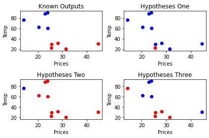

```python
#Plotting the results
x_axis = df['Prices']
y_axis = df['Temp']
color_list = ['b' if i ==1 else 'r' for i in Y]
color_list2 = ['b' if i ==1 else 'r' for i in H[0]]
color_list3 = ['b' if i ==1 else 'r' for i in H[1]]
color_list4 = ['b' if i ==1 else 'r' for i in H[2]]
plt.subplot(2, 2, 1)
plt.xlabel('Prices')
plt.ylabel('Temp')
plt.title('Known Outputs')
plt.scatter(x_axis, y_axis, c = color_list);
plt.subplot(2, 2, 2)
plt.xlabel('Prices')
plt.ylabel('Temp')
plt.title('Hypotheses One')
plt.scatter(x_axis, y_axis, c = color_list2);
plt.subplot(2, 2, 3)
plt.xlabel('Prices')
plt.ylabel('Temp')
plt.title('Hypotheses Two')
plt.scatter(x_axis, y_axis, c = color_list3);
plt.subplot(2, 2, 4)
plt.xlabel('Prices')
plt.ylabel('Temp')
plt.title('Hypotheses Three')
plt.scatter(x_axis, y_axis, c = color_list4);
plt.tight_layout()
```

The plots above show the difference in the hypotheses results and the known outputs with the optimized threshold values for each function. It looks like hypotheses one and two were able to achieve 60% accuracy given the right threshold, while hypotheses three was able to achieve 80% at best. The three functions that I picked were made at random are are just linear combinations of the two inputs divided by a order of magnitude value.

Now lets look at how a perceptron learning algorithm can predict the outputs. I have rewritten the algorithm from class and used it to predict the outputs.

```python
#Core functions needed for PLA algorithm
#Returns the h(x) value, 0 or 1
def activation(x):
    return np.where(x >= 0, 1, 0)
#Calculating the sign(...) from above
def prediction(x, weights):
    linear_value = np.dot(x, weights.T)
    predict_value = activation(linear_value)
    return predict_value
#Updating the weights to correct for misclassification
def fit(X, Y, weights):
    for i in range(1000): #1000 iterations
        for k in range(Y.shape[0]):
            x = np.insert(X[k], 0, 1)
            y = prediction(x, weights)
            difference_value = Y[k] - y
            weights = weights + learning_rate * difference_value * x
    print('The optimized weights are ' + str(weights))
    return weights
```

```python
#Setting the initial conditions
weights = np.array([np.random.rand(), np.random.rand(), np.random.rand()])
learning_rate = 0.1
```

```python
#Calculating the weights
final_weights = fit(X,Y, weights)
#Pulling the individual values our of the weights vector
b = final_weights[0]
w1 = final_weights[1]
w2 = final_weights[2]
#This is the line from w*x + b =0
decision_boundry_1 = ((-w1 / w2)) * X + ((-b) / w2)
```

```
The optimized weights are [ 0.50849997 -7.83558584  6.45702485]
```

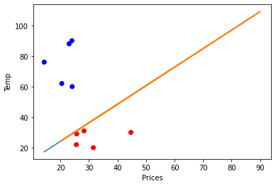

```python
#Plotting the results
x_axis = df['Prices']
y_axis = df['Temp']
plt.xlabel('Prices')
plt.ylabel('Temp')
color_list = ['b' if i ==1 else 'r' for i in Y]
plt.scatter(x_axis, y_axis, c = color_list)
plt.plot(X, decision_boundry_1);
```

We can see that the boundry has seperated the outputs as they should be. This would be said to have 100% accuracy when compared to the hypotheses above.

To conclude, the PLA was able to predict the outcomes much better than any of the hypotheses.